# Milestone Report - SwiftKey Project

Yoni DAHAN

Monday, July 20, 2015

# SwiftKey Project - Milestone Report

## Description

This report aims to provide some insight about the data and develops on the model building strategy that will be applied further on.  
The data is from the **HC Corpora** and is downloadable here. It is provided in a plenty of languages, but the english files will be mostly used at this stage.

For each language, it consists of three text files from **blogs**, **news** and **twitter** feed, which brings a representative specimen of the everyday written language.  
The R-code needed to perform the following analysis is available in my GitHub repository.

### Clarification

- The notation **n-gram** stands for *n-successive words*. For instance, considering the precedent phrase, its 2-grams are *“The notation”*, *“notation n-gram”*, *“n-gram stands”*, *“stands for”*, *“for n-successive”*, *“n-successive words”*.
- Deliberately, the **stopwords** - the most common words, such as “the”, “an”, “we”, “which”… - will not be removed in order to preserve the grammatical sentence structure.
- Likewise, the **profanities** will be kept. However, the model built will not predict them.
- For this analysis, the three files are gathered in a unique corpora

## Basic Summary

Here is a basic summary of the three files. For each file, “MeanLine” and “MaxLine” indicate respectively the mean and max number of characters per line :

[output not shown]

The character limit of a tweet is illustrated by the low max number of characters per line of the tweeter corpus.

## Pre-processing

### Sampling

Due to memory constraints, only a random sample of 5% of the entire corpora will be used.  
The subsequent analysis will show that it can cover most of the word occurences in the language.

### Cleaning

Prior to studying the features and highlighting some of its characteristics, the corpora should be cleaned as to appear in a normalized form. This will be performed in following these steps :

1. Convert **upper characters** to lower ones
2. Handling **english contractions**. In other words, fixing the issue of “I’m”, “I am”,“they’re”, “they are”… which can be counted erroneously as different n-grams
3. Remove **URL’s, e-mail adresses and twitter public replies**
4. Remove **hashtags**
5. Remove **numbers**
6. Remove **punctuation**
7. Remove words with more than **two successive same letters**, like “grrrrr” or “aaaaah” which aren’t correct english words
8. Remove **extra whitespaces**

## Features of the Data

```
  [1] "There are 63134 unique 1-grams (words) in the sampled corpora"
```

```
  [1] "There are 528301 unique 2-grams in the sampled corpora"
```

```
  [1] "There are 982659 unique 3-grams in the sampled corpora"
```

However, most of them are used very rarely :

```
  [1] "1-grams that are present in only 1% of the documents represent 99.72% of the total number of 1-grams"
```

```
  [1] "2-grams that are present in only 1% of the documents represent 99.99% of the total number of 2-grams"
```

[output not shown]

The following plot illustrates this fact :

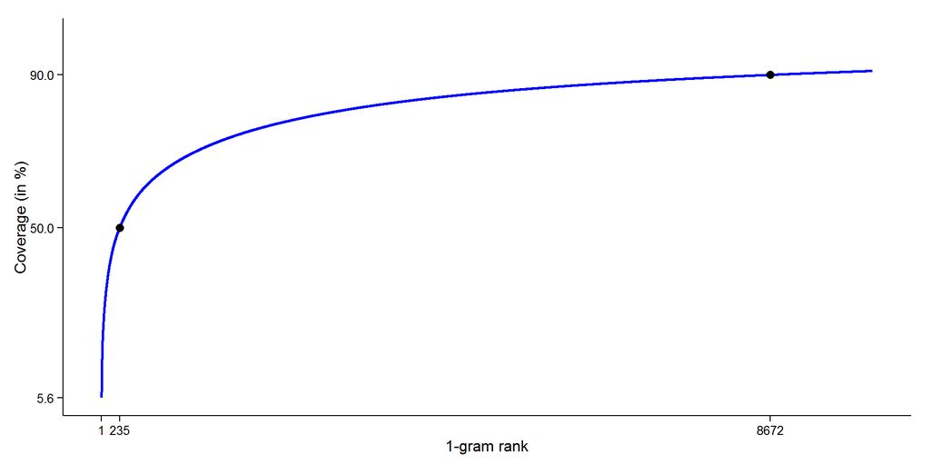

```
  [1] "The first 235 most frequent words cover 50% of all word instances in the sampled corpus"
```

```
  [1] "The first 8672 most frequent words cover 90% of all word instances in the sampled corpus"
```

This pattern can be linked with the [Zipf’s Law](https://en.wikipedia.org/wiki/Zipf%27s_law) which states that the number #1 word is used twice as the second, and so on.

That is, exploiting this phenomenon will lead to **data compression and better efficiency**, while preserving the accuracy.

We can now have a look at the distributions of the first forty 1-, 2 and 3-grams:

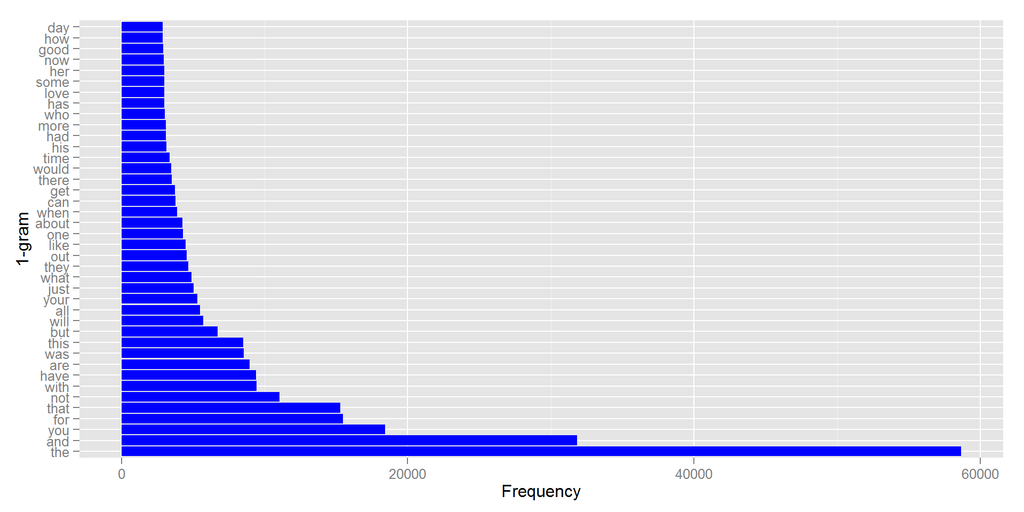

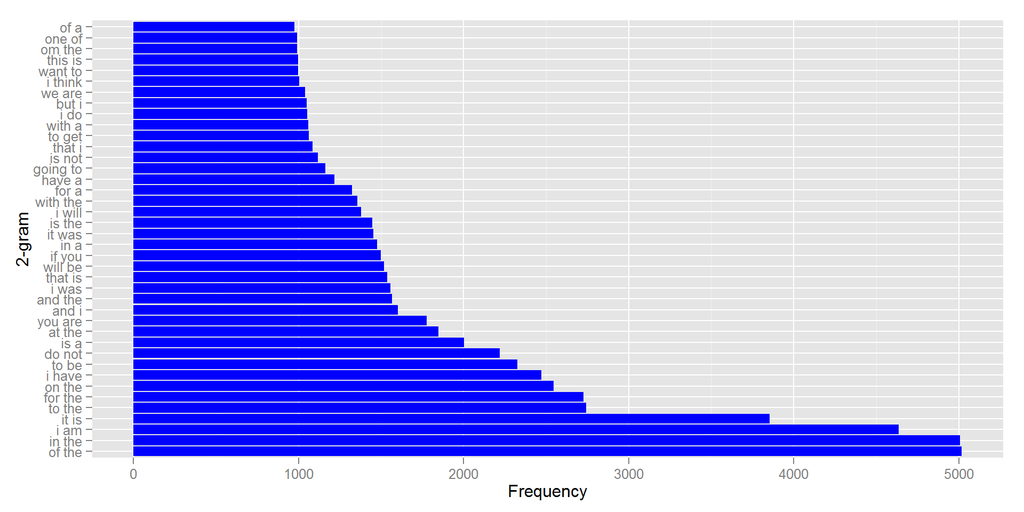

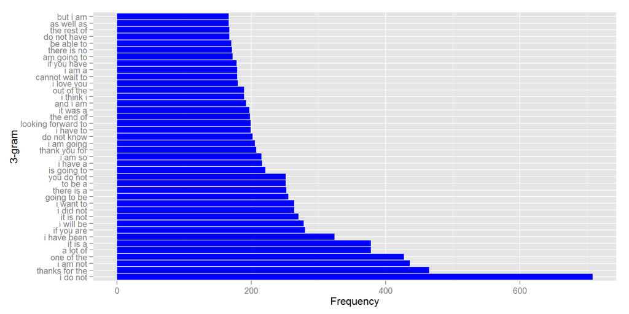

It is no surprise that most of the 1-, 2- and 3-grams are stopwords.  
When removing them, we can obtain this graph for the top forty 1-grams:

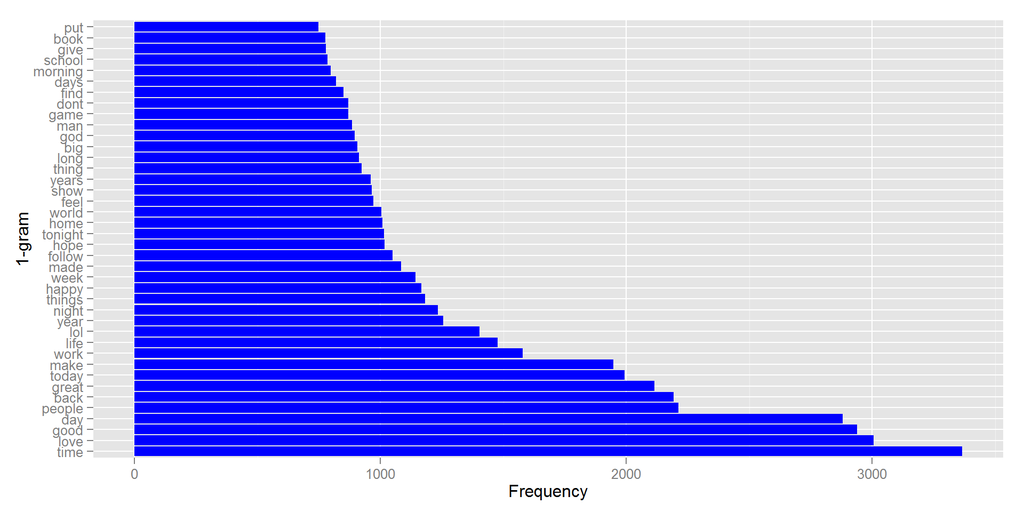

## Model Building Strategy

Further on, I will focus on these points :

- perform **sentence segmentation** as to generate higher level n-grams
- improve the **sampling process**: sampling enough to **increase representativeness**
- **estimate unobserved n-grams** with [*backoff models*](https://en.wikipedia.org/wiki/Katz%27s_back-off_model)
- use the knowledge of word frequencies to **reduce the size of the model**
- employ Markov chains for modelling
- create a Shiny app that predicts the next word based on a 3-gram input

## References

- [Lecture Slides from the Stanford Coursera course by Dan Jurafsky and Christopher Manning](https://web.stanford.edu/~jurafsky/NLPCourseraSlides.html)
- [Markov Chain - Wikipedia](https://en.wikipedia.org/wiki/Markov_chain)
- [HC Corpora - About the Corpora](http://www.corpora.heliohost.org/aboutcorpus.html)